© Guven

# Sequence Learning

## Introduction

In classical machine learning we have used a single data point $x \in \mathbb{R}^M$ to make a prediction based on the learned model at hand. The common assumptions in these methods are,

- Features are independent
- Data points have no dependence to their order, i.e. a shuffle would not change the performance

When the knowledge is carried by a sequence of data points $\langle x_t \rangle$, such as speech, video, events on a network, etc., the learning method is called sequence learning. In previous modules, we have briefly seen the Hidden Markov Model which is one of the major sequence learning methods.

### Sequence Problems

- Sequence prediction
  - Forecasting, product recommendation
- Sequence classification
  - Bioinformatics, anomaly detection, program execution
- Sequence generation
  - Text generation, handwriting generation, music generation
- Sequence to sequence prediction
  - Multi-Step time series forecasting, text summarization, program execution

### Recurrent Neural Networks

Sequences can be represented naturally on the directed graphs of Recurrent Neural Networks (RNN). Similar to state machines of Hidden Markov Models (HMM), RNN hidden states can retain the information temporally thus being able to represent the knowledge carried by the sequence of data points.

This module inspects sequence learning in the scope of neural networks by the use of Recurrent Neural networks. Use GloVe word embeddings to represent the sentences. An initial parsing and tokenization helps to achieve a cleaner input.

## Sequence-to-Sequence Models

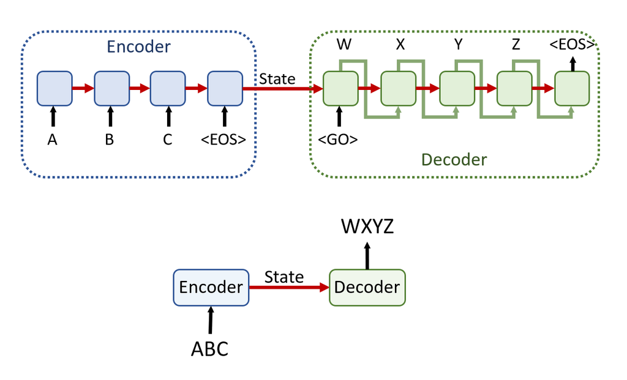

Recurrent neural network can have multiple input-output combinations depending on the output(s) connected to the hidden layers (i.e. state/memory/thought layers), such as one-to-one, one-to-many, many-to-one, and many-to-many. We have seen many-to-one as the RNN LSTM in the previous modules.

We will focus on the indirect many-to-many or sequence-to-sequence (seq2seq), where an input sequence is transformed into another, different output sequence, not necessarily with the same length as the input. Machine translation is one of the most popular types of seq2seq task which is also called neural machine translation (NMT) on a single neural network. The input sequences are the words of a sentence in one language and the output sequences are the words of the same sentence translated into another language. For example, we can translate the English sequence 'how are you' to the Finnish 'Mitä kuuluu'. Not only is the output sentence a different length, but there is no obvious direct correspondence between the elements of the input and output sequences.

The attention mechanism which supports seq2seq tasks allows direct access to any element of the input sequence. This is unlike a recurrent neural network (RNN), which summarizes the whole sequence in a single hidden state vector and prioritizes recent sequence elements over older ones. RNNs in a way is suited for solving tasks with indirect many-to-many relationships between the input and the output. The following is a diagram of the seq2seq model. The input sequence `[A, B, C, <EOS>]` is decoded into the output sequence `[<GO>, W, X, Y, Z, <EOS>]`.

Similar to the previous approaches we have seen, the seq2seq model solves the problem of varying input/output sequence lengths by encoding the input sequence in a fixed-length state vector and then using this vector as a base to generate the output sequence. The model tries to maximize the following probability.

$P(y_1,\dots,y_{T_o} \mid x_1,\dots,x_T) = \prod\limits_{t=1}^{T_o} P(y_t \mid \mathbf{v}, y_1,\dots,y_{t-1})$

where $\mathbf{x}$ is the input sequence $\langle x_t \rangle$ with length $T$, $\mathbf{y}$ is the output sequence $\langle y_t \rangle$ with $T_o$, $\mathbf{v}$ is the fixed length encoding of the input sequence.

### The Need for the Attention

The decoder has to generate the entire output sequence based solely on the hidden (i.e. state/memory/thought) vector. The hidden vector has to encode all of the information of the input sequence. The encoder is an RNN, so that its hidden state will carry more information about the latest sequence elements than the earliest. Using LSTM cells and reversing the input helps, but cannot prevent it entirely. Thus, the hidden vector situation is needed to be improved by iterating the *attention* starting from start to finish. In other words, the seq2seq model works well for short sentences, but its performance deteriorates for longer sentences.

## Time Series Forecasting

Classical time series forecasting methods are based on moving average, autoregressive ARIMA, Holt Winters, and spectral methods. Sequence learners such as LSTM can use one-dimensional features generated by `Conv1D` to design time-series forecasting by Conv1D-LSTM neural networks. The Conv1D can extract features and smoothen the input time series and then LSTMs can model these sequences.

ARIMA models combine two of the most common time series modeling formats, Auto Regressive (AR) and a Moving Average (MA) models. The AR model is constructed from the given series $\langle x_t \rangle$ so that the modeled $y$ depends only on its own lags. The MA model is constructed so that $y$ depends on the lagged forecast errors.

Non-seasonal $\text{ARIMA}(p,d,q)$ models are comprised of three terms $p$, $d$, and $q$.

- $p$ the order of the Auto Regressive term (the number of lags of $y$ that are used as predictors)
- $d$ the minimum number of difference-ing needed to make the time series stationary
- $q$ the order of the Moving Average Term (number of lagged forecast errors that should go into the ARIMA model)

The auto regressive model of order $p$ is given by,

$y_t = c + \phi_1 x_{t-1} + \phi_2 x_{t-2} + \dots + \phi_p x_{t-p} + \varepsilon_t$

The moving average model of order $q$ is given by,

$y_t = c + \varepsilon_t + \theta_1 \varepsilon_{t-1} + \theta_2 \varepsilon_{t-2} + \dots + \theta_q \varepsilon_{t-q}$

### Holt Winters

In the late 1950s, basic exponential smoothing was proposed as one of the first time-series forecasting methods. In its simplest form,

$y_t = \alpha x_t + (1-\alpha) y_{t-1}$, $0<t$, $0 \leq \alpha \leq 1$

where $\langle x_t \rangle$ is the raw data sequence to be smoothed, $\langle y_t \rangle$ is the output of the smoothing algorithm (also called the estimate), and $\alpha$ is the smoothing parameter. This equation is used to calculate $y$ recursively ($y_{t-1}$ is the most recent forecast) beginning with $y_0=x_0$. An exponential decrease of weights is achieved when the value of $\alpha$ is set between $0$ and $1$, as can be seen in the following equation, which is based upon the recurrent equation above.

$y_t = \alpha \left[ x_t+(1-\alpha) x_{t-1}+(1-\alpha)^2 x_{t-2}+(1-\alpha)^3 x_{t-3}+ \dots +(1-\alpha)^{t-1} x_1 \right]+(1-\alpha)^t x_0$

In order to determine the operational value of $\alpha$, an optimization stage is applied using the provided raw data series and minimizing the error between the raw data and estimated values. Hence, the exponential smoothing model can be fit to the input raw data. Error functions are used to measure the deviation of the model predictions from the actual data, such as,

Root Mean Squared Error: $\text{RMSE} = \sqrt{(\frac{1}{n} \sum_{i=1}^n (y_t-x_i)^2}$

Mean Absolute Relative Error: $\text{MARE} = \sum_{i=1}^n \left|\frac{y_t-x_i}{y_t+1}\right|$

When the data contain enough seasonality resulting in an applicable periodicity, then Holt Winters seasonal smoothing method may be used. There are two variations of this modeling approach: additive and multiplicative. The additive model is used when the seasonal variations are roughly constant through the time series. In this case, the seasonal components will sum to zero. The multiplicative model is used when the seasonal variations are proportional to the level of the data. Within each period, the seasonal component will add up to $m$, the period of seasonality. The following set of equations define the additive model,

$y_{t+1} = a_t+b_t+s_{t-m}$  
$a_t = \alpha(y_t-s_{t-m})+(1-\alpha)(a_{t-1}+b_{t-1})$  
$b_t = \beta(a_t-a_{t-1})+(1-\beta) b_{t-1}$  
$s_t = \gamma(y_t-a_{t-1}-b_{t-1})+(1-\gamma) s_{t-m}$

In the above equations, $\alpha$ is the smoothing factor, ($0<\alpha<1$), $\beta$ is the trend smoothing factor ($0<\beta<1$), $\gamma$ is the seasonal change smoothing factor ($0<\gamma<1$). Similar to the basic exponential model approach, solving an optimization problem to find $\{\alpha,\beta,\gamma\}$ fits the Holt Winters seasonal additive exponential smoothing model to the raw data. The optimization is performed in such a way that a given metric (RMSE or MARE) is optimized for the prediction one step ahead ($t+1$).

## Example Time Series Forecasting

The problem is forecasting energy usage using the PJME dataset.

First let's have a look at forecasting using a regressor model such as XGBoost. Install with `conda install -c conda-forge xgboost`. The feature extraction for the regressor is based on different time units as in the following example.

Next, we will compare a `Conv1D` neural network performance to the regressor.

```python
%matplotlib inline
import matplotlib.pyplot as plt
plt.rcParams['figure.dpi'] = 72
from IPython.display import display
import matplotlib.dates as mdates
from matplotlib.ticker import NullFormatter, FuncFormatter
import numpy as np
import pandas as pd
import os
import sys

import xgboost as xgb
```

```python
# get the dataset
df = pd.read_csv('../../../EP_datasets/PJME_hourly.csv', parse_dates=[0])  # parse dates
df = df.sort_values(by='Datetime')
df = df.reset_index(drop=True)

# sanity
display(df.head())
print(f'#rows= {len(df)}')
```

|  | Datetime | PJME_MW |
| --- | --- | --- |
| 0 | 2002-01-01 01:00:00 | 30393.0 |
| 1 | 2002-01-01 02:00:00 | 29265.0 |
| 2 | 2002-01-01 03:00:00 | 28357.0 |
| 3 | 2002-01-01 04:00:00 | 27899.0 |
| 4 | 2002-01-01 05:00:00 | 28057.0 |

```
#rows= 145366
```

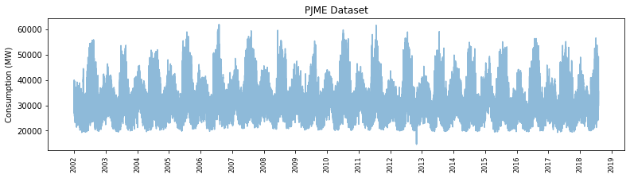

```python
fig, ax = plt.subplots(1, figsize=(13, 3), dpi=72)

ax.plot(df['Datetime'], df['PJME_MW'], alpha=0.5)
ax.xaxis.set_major_locator(mdates.YearLocator())
ax.xaxis.set_major_formatter(mdates.DateFormatter('%Y'))
ax.set(ylabel='Consumption (MW)', title='PJME Dataset')
plt.setp(ax.get_xticklabels(), rotation=90, fontsize=8)
plt.show()
```

```python
DATE_SPLIT = '01-Jan-2015'  # arbitrary

df_train = df.loc[df.Datetime <= DATE_SPLIT].copy()
df_test = df.loc[df.Datetime > DATE_SPLIT].copy()

# sanity
print(len(df_train), len(df_test))
```

```
113927 31439
```

```python
def get_features(_df):
    _df['hour'] = _df.Datetime.dt.hour
    _df['dayofweek'] = _df.Datetime.dt.dayofweek
    _df['quarter'] = _df.Datetime.dt.quarter
    _df['month'] = _df.Datetime.dt.month
    _df['year'] = _df.Datetime.dt.year
    _df['dayofyear'] = _df.Datetime.dt.dayofyear
    _df['dayofmonth'] = _df.Datetime.dt.day
    _df['weekofyear'] = _df.Datetime.dt.isocalendar().week

    X = _df[[_ for _ in _df.columns if not _ in ['Datetime','PJME_MW']]].values
    y = _df.PJME_MW.values.ravel()
    return X, y

Xtr, ytr = get_features(df_train)
Xts, yts = get_features(df_test)
```

```python
from xgboost import plot_importance

# create the regressor
reg = xgb.XGBRegressor(n_estimators=1000, early_stopping_rounds=50)
reg.fit(Xtr, ytr, eval_set=[(Xtr, ytr), (Xts, yts)], verbose=False)

COLS = [_ for _ in df_train.columns if not _ in ['Datetime','PJME_MW']]
reg.get_booster().feature_names = COLS
```

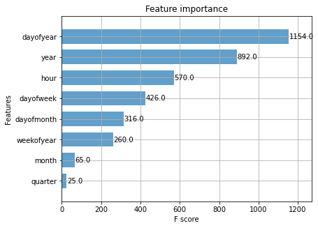

```python
plot_importance(reg.get_booster(), height=0.7, alpha=0.7)
plt.show()
```

```python
from sklearn.metrics import mean_squared_error, mean_absolute_percentage_error

# test, forecast, MSE error, and plot
df_test['MW_Prediction'] = reg.predict(Xts)

mse = mean_squared_error(df_test['PJME_MW'].values, df_test['MW_Prediction'].values)
print(f'MSE= {mse:,.0f}')

mape = mean_absolute_percentage_error(df_test['PJME_MW'].values, df_test['MW_Prediction'].values)
print(f'MAPE= {mape:.5f}')
```

```
MSE= 13,960,913
MAPE= 0.08511
```

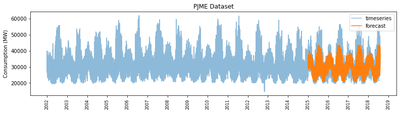

```python
fig, ax = plt.subplots(1, figsize=(13, 3), dpi=72)

# debug
# ax.plot(df['Datetime'][145000:], df['PJME_MW'][145000:], label='timeseries', alpha=0.5)

ax.plot(df['Datetime'], df['PJME_MW'], label='timeseries', alpha=0.5)
ax.plot(df_test['Datetime'], df_test['MW_Prediction'], label='forecast')

ax.xaxis.set_major_locator(mdates.YearLocator())
ax.xaxis.set_major_formatter(mdates.DateFormatter('%Y'))
ax.set(ylabel='Consumption (MW)', title='PJME Dataset')
plt.setp(ax.get_xticklabels(), rotation=90, fontsize=8)

# debug
# ax.plot(df_test['Datetime'][31000:], df_test['MW_Prediction'][31000:], label='forecast')

plt.legend()
plt.show()
```

```python
# prediction
def pred(_c1_nn, _Xts):
    y_pred_ = []
    for _ in range(_Xts.shape[3]):
        y_pred_ += _c1_nn(_Xts[:,:,:,_]).cpu().flatten().tolist()
    return np.array(y_pred_)
```

```python
import torch
import torch.nn as nn

Gpu = torch.device("cuda:0" if torch.cuda.is_available() else "cpu")

CNN_FILTERS_N= 32

SEQ_SIZE= 24
BATCH_SIZE= 64

c1_nn = nn.Sequential(
    # Conv1d -> (?, SEQ_SIZE, CNN_FILTERS_N)
    nn.Conv1d(1, CNN_FILTERS_N, 5, stride=1, padding=0, bias=False),
    nn.ReLU(inplace=True),
    nn.BatchNorm1d(CNN_FILTERS_N),

    nn.Conv1d(CNN_FILTERS_N, 2*CNN_FILTERS_N, 5, stride=1, padding=0, bias=False),
    nn.ReLU(inplace=True),
    nn.BatchNorm1d(2*CNN_FILTERS_N),

    nn.Flatten(start_dim=1),
    nn.Linear(2*CNN_FILTERS_N * 16, SEQ_SIZE),
).to(Gpu)

print(c1_nn)
```

```
Sequential(
  (0): Conv1d(1, 32, kernel_size=(5,), stride=(1,), bias=False)
  (1): ReLU(inplace=True)
  (2): BatchNorm1d(32, eps=1e-05, momentum=0.1, affine=True, track_running_stats=True)
  (3): Conv1d(32, 64, kernel_size=(5,), stride=(1,), bias=False)
  (4): ReLU(inplace=True)
  (5): BatchNorm1d(64, eps=1e-05, momentum=0.1, affine=True, track_running_stats=True)
  (6): Flatten(start_dim=1, end_dim=-1)
  (7): Linear(in_features=1024, out_features=24, bias=True)
)
```

```python
# size of the neural network
def count_parameters(model):
    return sum(p.numel() for p in model.parameters())

count_parameters(c1_nn)
```

```
35192
```

```python
# For LSTM Tensor dimensions: B x T x M
Xtr_, Xts_ = torch.FloatTensor(df_train['PJME_MW'].values), torch.FloatTensor(df_test['PJME_MW'].values)
N2 = Xtr_.shape[0] // (BATCH_SIZE*SEQ_SIZE)
Xtr = Xtr_[:BATCH_SIZE*SEQ_SIZE*N2].reshape((BATCH_SIZE,1,SEQ_SIZE,N2)).to(Gpu)
N2 = Xts_.shape[0] // (BATCH_SIZE*SEQ_SIZE)
Xts = Xts_[:BATCH_SIZE*SEQ_SIZE*N2].reshape((BATCH_SIZE,1,SEQ_SIZE,N2)).to(Gpu)

print(Xtr_.shape, Xtr.shape, Xts_.shape, Xts.shape)
```

```
torch.Size([113927]) torch.Size([64, 1, 24, 74]) torch.Size([31439]) torch.Size([64, 1, 24, 20])
```

```python
info = True

EPOCHS= 100

loss_func  = torch.nn.MSELoss()
optim = torch.optim.Adam(c1_nn.parameters(), lr=0.0005, weight_decay=1e-5)

for e in range(EPOCHS):
    for i in range(Xtr.shape[3]):

        net_out = c1_nn(Xtr[:,:,:,i])

        loss = loss_func(net_out, Xtr[:,:,:,i].reshape(BATCH_SIZE,SEQ_SIZE))
        loss.backward()
        optim.step()

    if info:
        with torch.no_grad():
            y_pred = pred(c1_nn, Xts)
        mape = mean_absolute_percentage_error(y_pred, Xts.cpu().flatten())
        sys.stderr.write(f"\r{e+1:03d}/{EPOCHS:3d} | Loss: {loss:12.2f} | MAPE: {mape:.5f}")
        sys.stderr.flush()
```

[output not shown]

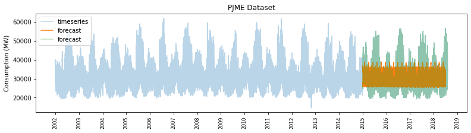

```python
y = pred(c1_nn, Xts)

fig, ax = plt.subplots(1, figsize=(13, 3), dpi=72)

ax.plot(df['Datetime'], df['PJME_MW'], label='timeseries', alpha=0.3)
ax.xaxis.set_major_locator(mdates.YearLocator())
ax.xaxis.set_major_formatter(mdates.DateFormatter('%Y'))
ax.set(ylabel='Consumption (MW)', title='PJME Dataset')
plt.setp(ax.get_xticklabels(), rotation=90, fontsize=8)

ax.plot(df_test['Datetime'][:len(y)], y, label='forecast')
ax.plot(df_test['Datetime'], df_test['PJME_MW'], label='forecast', alpha=0.3)

plt.legend()
plt.show()
```

```python
mse = mean_squared_error(df_test['PJME_MW'][:len(y)].values, y)
print(f'MSE= {mse:,.0f}')

mape = mean_absolute_percentage_error(df_test['PJME_MW'][:len(y)].values, y)
print(f'MAPE= {mape:.5f}')
```

```
MSE= 53,707,785
MAPE= 0.18010
```

## Example Seq2Seq Translation

Let's see an example of sequence to sequence network where two recurrent neural networks work together to transform one sequence to another.

### Dataset Example

The glue dataset is a sound benchmark dataset that might help assignments, and projects in this course.

Install libraries: `conda install transformers datasets`

Additional datasets and related work example https://nlp.stanford.edu/projects/nmt/.

```python
MODEL_PATH= '../../../EP_models/'
os.environ['TRANSFORMERS_CACHE'] = MODEL_PATH  # before import transformers
os.environ['HF_DATASETS_CACHE'] = MODEL_PATH

import datasets

# filter warnings
datasets.logging.set_verbosity_error()

mnli_tr = datasets.load_dataset('glue', 'mnli', split='train')
mnli_tr
```

```
Dataset({
    features: ['premise', 'hypothesis', 'label', 'idx'],
    num_rows: 392702
})
```

### Translation Example

Next we will demonstrate a translation with the english-french dataset (Sutskever, 2014). The module file `nmt_dataset.py`, neural machine translation Python script, helps load the dataset `eng-fra.txt` TSV file. Place this script in the same folder.

The encoder and decoder are two separate LSTMs which help training different decoders with the same encoder. LSTMs with more than one layer perform better than the ones with a single layer. The input sequence is fed to the decoder in reverse, e.g., `ABC` $\longrightarrow$ `WXYZ` would be `CBA` $\longrightarrow$ `WXYZ`. In the cited paper authors have stated subjectively that since this is a step-by-step model, if the sequences were in normal order, each source word in the source sentence would be far from its corresponding word in the output sentence. If we reverse the input sequence, the average distance between input/output words will not change, but the first input words will be very close to the first output words. This will help the model to establish better relation between the input and output sequences.

Besides `<EOS>` and `<GO>`, the model uses two other special symbols `<UNK>` for the unknown (used to replace rare words so that the term is skipped in the vocabulary), `<PAD>` to pad (to fill sequences for a fixed length).

```python
sys.path.insert(1, './nmt_dataset/.')

from nmt_dataset import NMTDataset, GO_token, EOS_token, MAX_LENGTH

DATASET_SIZE = 40000  # skipping some rows

dataset = NMTDataset('nmt_dataset/eng-fra.txt', DATASET_SIZE)
```

```python
HIDDEN_N= 128

class Encoder(torch.nn.Module):
    def __init__(self, n_input, n_hidden):
        super().__init__()
        self.n_input, self.n_hidden = n_input, n_hidden

        # embedding layer
        self.embedding = torch.nn.Embedding(self.n_input, self.n_hidden)

        # RNN cell
        self.rnn_cell = torch.nn.GRU(self.n_hidden, self.n_hidden)

    def forward(self, _X, _hn):
        # single sequence
        X_embedded = self.embedding(_X).view(1, 1, -1)
        output, hn = self.rnn_cell(X_embedded, _hn)
        return output, hn

    def init_hidden(self):
        return torch.zeros(1, 1, self.n_hidden, device=Gpu)

class Decoder(torch.nn.Module):
    def __init__(self, n_hidden, n_output, dropout=0.1):
        super().__init__()
        self.n_hidden, self.n_output = n_hidden, n_output

        self.embedding = torch.nn.Embedding(self.n_output, self.n_hidden)

        self.dropout = torch.nn.Dropout(dropout)

        self.attn = torch.nn.Linear(in_features=self.n_hidden,
                                    out_features=self.n_hidden)

        self.w_c = torch.nn.Linear(in_features=self.n_hidden*2,
                                   out_features=self.n_hidden)

        self.rnn_cell = torch.nn.GRU(input_size=self.n_hidden,
                                     hidden_size=self.n_hidden)

        # output
        self.w_y = torch.nn.Linear(in_features=self.n_hidden,
                                   out_features=self.n_output)

    def forward(self, _X, _hn, _encoder_outputs):
        X_embedded = self.embedding(_X).view(1, 1, -1)
        X_embedded = self.dropout(X_embedded)

        # hidden state, time t
        rnn_out, hn = self.rnn_cell(X_embedded, _hn)

        # alignment scores
        alignment_scores = torch.mm(self.attn(hn)[0], _encoder_outputs.t())

        # weights
        attn_weights = torch.nn.functional.softmax(alignment_scores, dim=1)

        # multiplicative attention context vector c_t
        c_t = torch.mm(attn_weights, _encoder_outputs)

        # concatenate h_t and the context
        hidden_s_t = torch.cat([hn[0], c_t], dim=1)

        # hidden context
        hidden_s_t = torch.tanh(self.w_c(hidden_s_t))

        # output
        output = torch.nn.functional.log_softmax(self.w_y(hidden_s_t), dim=1)

        return output, hn, attn_weights

    def init_hidden(self):
        return torch.zeros(1, 1, self.n_hidden, device=Gpu)
```

```python
encoder = Encoder(dataset.input_lang.n_words, HIDDEN_N).to(Gpu)
decoder = Decoder(HIDDEN_N, dataset.output_lang.n_words, dropout=0.1).to(Gpu)

dt_loader = torch.utils.data.DataLoader(dataset, batch_size=1, shuffle=False)
N = len(dt_loader.dataset)

e_optim = torch.optim.Adam(encoder.parameters())
d_optim = torch.optim.Adam(decoder.parameters())
loss_func = torch.nn.NLLLoss()
```

```python
%%time

def train(_enc, _dec, info=False):
    totloss = 0
    for i, (seq1, seq2) in enumerate(dt_loader):
        seq1 = seq1.to(Gpu).squeeze(0)
        seq2 = seq2.to(Gpu).squeeze(0)

        e_hn = _enc.init_hidden()  # hidden layer

        e_optim.zero_grad()
        d_optim.zero_grad()

        Nseq1 = seq1.size(0)  # input length
        Nseq2 = seq2.size(0)  # target length

        e_outputs = torch.zeros(MAX_LENGTH, _enc.n_hidden, device=Gpu)

        loss = torch.Tensor([0]).squeeze().to(Gpu)

        with torch.set_grad_enabled(True):
            # encoder
            for ei in range(Nseq1):
                e_output, e_hn = _enc(seq1[ei], e_hn)
                e_outputs[ei] = e_output[0, 0]

            # init decoder with GO_token
            d_input = torch.tensor([[GO_token]], device=Gpu)

            d_hn = e_hn  # hidden layer

            for di in range(Nseq2):
                d_output, d_hn, d_attn = _dec(d_input, d_hn, e_outputs)
                loss += loss_func(d_output, seq2[di])
                d_input = seq2[di]

            loss.backward()

            e_optim.step()
            d_optim.step()

        totloss += loss.item()/Nseq2

        DBG_STEP = 1000
        if info:
            if i % DBG_STEP == 0:
                sys.stderr.write(f"\r{i//DBG_STEP:3d}/{N//DBG_STEP:03d} | Loss: {totloss/DBG_STEP:3.2f}")
                sys.stderr.flush()
                totloss = 0


train(encoder, decoder, info=True)
```

```
 39/040 | Loss: 0.89
```

```
CPU times: total: 7min 49s
Wall time: 7min 54s
```

```python
def eval_ss(_enc, _dec, _seq1, max_length=MAX_LENGTH):
    with torch.no_grad():
        Nseq1 = _seq1.size()[0]
        e_hn = _enc.init_hidden()
        _seq1.to(Gpu)

        e_outputs = torch.zeros(max_length, _enc.n_hidden, device=Gpu)

        for ei in range(Nseq1):
            e_output, e_hn = _enc(_seq1[ei], e_hn)
            e_outputs[ei] += e_output[0, 0]

        d_input = torch.tensor([[GO_token]], device=Gpu)

        d_hn = e_hn  # hidden layer

        d_words = []
        d_attentions = torch.zeros(max_length, max_length)

        for di in range(max_length):
            d_output, d_hn, d_attn = _dec(d_input, d_hn, e_outputs)
            d_attentions[di] = d_attn.data

            # output word index with highest P
            _, topi = d_output.data.topk(1)
            if topi.item() != EOS_token:
                d_words.append(dataset.output_lang.index2word[topi.item()])
            else:
                break

            d_input = topi.squeeze().detach()

        return d_words, d_attentions[:di+1]


def eval_rnd(_enc, _dec, n=10):
    import random
    for _ in range(n):
        sample = random.randint(0, N-1)
        pair = dataset.pairs[sample]
        seq1 = dataset[sample][0].to(Gpu)

        output_words, attentions = eval_ss(_enc, _dec, seq1)

        print(f"seq1:{pair[0]} | seq2:{pair[1]} | result:{' '.join(output_words)}")


eval_rnd(encoder, decoder)
```

```
seq1:il est physicien . | seq2:he is a physicist . | result:he s a beginner .
seq1:c est mon heros . | seq2:he s my hero . | result:he s my hero .
seq1:il s affaire aux preparatifs du voyage . | seq2:he is busy preparing for the trip . | result:he s going to the trip .
seq1:je suis musulman . | seq2:i am a muslim . | result:i m a muslim .
seq1:je ne suis pas si veinard . | seq2:i m not so lucky . | result:i m not that desperate .
seq1:je suis desole de vous avoir derange . | seq2:i m sorry to have disturbed you . | result:i m sorry i hurt you .
seq1:tu es mon meilleur ami . | seq2:you are my best friend . | result:you re my friend .
seq1:il craint de commettre des erreurs . | seq2:he s afraid of making mistakes . | result:he is afraid of making mistakes .
seq1:elle a promis qu elle allait m appeler . | seq2:she s promised to give me a ring . | result:she is absorbed to give me .
seq1:je voyage leger . | seq2:i m traveling light . | result:i m actually french .
```

## Example Sentiment Detection

Apply the RNN to the problem of sentiment detection in the IMDB movie review database we have used for the assignments.

The following example uses the `nn.LSTM` module.

```python
import torch
import torch.nn as nn

print(f'PyTorch version= {torch.__version__}')
print(f'CUDA available= {torch.cuda.is_available()}')
```

```
PyTorch version= 2.1.0
CUDA available= True
```

```python
if torch.cuda.is_available():
    # CUDA Installation
    print('CUDA Version')
    !nvcc --version
    print()

    # CUDNN Installation
    print(f'CUDNN Version: {torch.backends.cudnn.version()}')
    print(f'Number of CUDA Devices: {torch.cuda.device_count()}')
    print(f'Active CUDA Device: {torch.cuda.current_device()}')
    print(f'Available devices: {torch.cuda.device_count()}, Name: {torch.cuda.get_device_name(0)}')
    print(f'Current CUDA device: {torch.cuda.current_device()}')

# Set the GPU to device 0
gpu = torch.device('cuda:0')
```

```
CUDA Version
nvcc: NVIDIA (R) Cuda compiler driver
Copyright (c) 2005-2023 NVIDIA Corporation
Built on Tue_Aug_15_22:09:35_Pacific_Daylight_Time_2023
Cuda compilation tools, release 12.2, V12.2.140
Build cuda_12.2.r12.2/compiler.33191640_0

CUDNN Version: 8801
Number of CUDA Devices: 1
Active CUDA Device: 0
Available devices: 1, Name: NVIDIA RTX 5000 Ada Generation
Current CUDA device: 0
```

Read the data and prepare the data arrays as Tensors. The following implementation is batched and using embeddings of feature size `M=50` using GloVe embedding model. https://nlp.stanford.edu/projects/glove/

The `torchtext` library is used, install by `conda install -c pytorch torchtext`

**Note:** In case a URL error is returned, retry the `torchtext.vocab.GloVe` function below and load the pretrained word embedding files (around 900 MB zipped).

```python
import csv
import re

import torchtext

from string import punctuation
from nltk import word_tokenize
from nltk.corpus import stopwords

GLOVE_CACHE_PATH= '../../../EP_models/vector_cache'

# Embedding words from GloVe
Glove = torchtext.vocab.GloVe(name="6B", dim=50, max_vectors=2000, cache=GLOVE_CACHE_PATH)  # use 2k most common words

M = 50  # as directed by GloVe
```

```python
%%time

# Combination of stop words and punctuations
Stop_symbols = stopwords.words('english') + list(re.split('', punctuation)) + ['br'] + ["n't"]

# Locate and load the data file
Reviews, Sentiments = [], []
with open('../../../EP_datasets/movie_data.csv', 'r', encoding="utf8") as fin:
    reader = csv.reader(fin, delimiter=',', quotechar='"')
    header = next(reader)  # pass the header
    for line in reader:
        line[0] = re.sub('<br /><br />', ' ', line[0])  # HTML sourced reviews, break
        line[0] = re.sub(' \W+ ', ' ', line[0])  # Symbols

        terms = word_tokenize(line[0])
        # convert to lower case but only tokens with all caps
        terms = [_.lower() if re.search(r'^[A-Z]+$', _) else _ for _ in terms]
        # filter out tokens in stop words
        terms = [_ for _ in terms if _ not in Stop_symbols]
        # filter out tokens which start with non-letter
        terms = [_ for _ in terms if not re.search(r'^[^a-zA-Z]{1}', _)]

        Reviews += [terms]
        Sentiments += [int(line[1])]  # good to keep the class as integers

N = len(Reviews)
Reviews0 = [_ for i, _ in enumerate(Reviews) if Sentiments[i] == 0]
N0 = len(Reviews0)
Reviews1 = [_ for i, _ in enumerate(Reviews) if Sentiments[i] == 1]
N1 = len(Reviews1)

# Sanity check
print(f'Total reviews loaded {N}, N0={N0}, N1={N1}')
```

```
Total reviews loaded 50000, N0=25000, N1=25000
CPU times: total: 1min 14s
Wall time: 1min 14s
```

```python
N = len(Reviews)
Reviews0 = [_ for i, _ in enumerate(Reviews) if Sentiments[i] == 0 and i %99 == 0]
N0 = len(Reviews0)
Reviews1 = [_ for i, _ in enumerate(Reviews) if Sentiments[i] == 1 and i %99 == 0]
N1 = len(Reviews1)

# Sanity check
print(f'Total reviews loaded {N}, N0={N0}, N1={N1}')
```

```
Total reviews loaded 50000, N0=261, N1=245
```

```python
%%time

# Use GloVe word index and convert reviews a list of indices, then to numpy array
def reviews2glove(_reviews, _glove_vec):
    seqs = []
    for review in _reviews:  # keep words that has an embedding in GloVe
        idxs = [_glove_vec.stoi[w] for w in review if w in _glove_vec.stoi]
        if idxs:  # ignore reviews without any word with an embedding in GloVe
            seqs += [np.array(idxs)]
    return seqs

Seqs0 = reviews2glove(Reviews0, Glove)
Seqs1 = reviews2glove(Reviews1, Glove)
```

```
CPU times: total: 0 ns
Wall time: 0 ns
```

```python
# Sanity
review00 = [Glove.itos[_] for _ in Seqs0[0]]
print(review00)
print(len(review00))
review10 = [Glove.itos[_] for _ in Seqs1[0]]
print(review10)
print(len(review10))
```

```
['believe', 'best', 'ceremony', 'recent', 'years', 'two', 'reasons', 'saw', 'help', 'better', 'case', 'head', 'one', 'best', 'best', 'director', 'year', 'award', 'ceremony', 'bad', 'little', 'way', 'happy', 'see', 'return', 'king', 'awards', 'even', 'best', 'much', 'better', 'let', 'getting', 'round…
143
['area', 'house', 'murder', 'remained', 'years', 'later', 'writer', 'former', 'la', 'trial', 'moved', 'case', 'partner', 'writing', 'book', 'support', 'retired', 'charge', 'investigation', 'criminal', 'net', 'power', 'money', 'cover', 'murder', 'good', 'tv', 'movie', 'true', 'story', 'murder', 'year…
55
```

```python
# Use the GloVe embedding
glove_embed = nn.Embedding.from_pretrained(Glove.vectors)

# Sanity
print(glove_embed(torch.tensor(Seqs0[0],dtype=torch.int64)).shape)
print(glove_embed(torch.tensor(Seqs1[0],dtype=torch.int64)).shape)
```

```
torch.Size([143, 50])
torch.Size([55, 50])
```

```python
# Convert words to M dimensional tensors via GloVe embedding
Seqs0 = [glove_embed(torch.tensor(_,dtype=torch.int64)) for _ in Seqs0]
Seqs1 = [glove_embed(torch.tensor(_,dtype=torch.int64)) for _ in Seqs1]
```

```python
T = 100

# Limit sequence length to T
def seq_limit(_seqs):
    for i, t in enumerate(_seqs):
        L = t.shape[0]
        if L > T:
            _seqs[i] = t.narrow(0,0,T)
        elif L < T:
            t2 = torch.zeros((T, M))  # append zeros
            t2[:L, :] = t
            _seqs[i] = t2

seq_limit(Seqs0)
seq_limit(Seqs1)
```

```python
from sklearn.model_selection import StratifiedKFold

# Fill the tuple list for reviews
def get_Xy():
    Xy  = [(s.type(torch.float32),torch.tensor([0], dtype=torch.int64)) for s in Seqs0]
    Xy += [(s.type(torch.float32),torch.tensor([1], dtype=torch.int64)) for s in Seqs1]
    return Xy

# Helper functions
def get_X(_Xy):
    return [_[0] for _ in _Xy]

def get_y(_Xy):
    return [int(_[1].data[0]) for _ in _Xy]

# Sanity
Xy = get_Xy()
print(len(Xy))
```

```
506
```

```python
# GPU memory limitations, predict the sequences batch by batch
def rnn_predict(_rnn, _Xy):
    K, y_pred, i, N = 5000, [], 0, len(_Xy)
    while i < N:
        X = get_X(_Xy)[i:i+K] if i+K < N else get_X(_Xy)[i:]
        y_pred += rnn.predict(X)
        i += K
    return y_pred
```

```python
# Borrowed from the past module
class My_RNN(nn.Module):

    def __init__(self, H, numH=1, epochs=10, eta=0.0005, B=100, weight=None, info=True):
        """ A PyTorch neural network model based on LSTM cell, batched """
        super(My_RNN, self).__init__()
        self.H, self.numH, self.epochs, self.eta, self.B, self.info = H, numH, epochs, eta, B, info

        self.rnn, self.outlayer = None, None

        self.softmax = nn.LogSoftmax(dim=1)
        self.criterion = nn.NLLLoss(weight=weight)

    def forward(self, _X, _h0):
        output, hn = self.rnn(_X, _h0)  # runs iteratively for the duration of the sequence
        output = self.outlayer(output[:, -1, :])  # output is batched
        output = self.softmax(output)
        return output, hn

    def init_rnn(self, _M):  # Create variations of our RNN by overriding init_rnn
        dropout = 0.5 if self.numH > 1 else 0
        return nn.LSTM(_M, self.H, self.numH,
                       bidirectional=False,
                       bias=True, batch_first=True, dropout=dropout)

    def init_hidden(self, _B):  # batch_first = True
        return (torch.zeros(self.numH, _B, self.H).to(gpu),
                torch.zeros(self.numH, _B, self.H).to(gpu))

    def init_outlayer(self, _C):  # override if necessary
        return nn.Linear(self.H, _C).to(gpu)

    def fit(self, _Xy):
        from random import shuffle
        import sys
        import torch.optim as optim

        M= _Xy[0][0].shape[1]  # number of features, based on batch input
        C= np.unique([int(_[1].data[0]) for _ in _Xy]).shape[0]  # number of class labels

        self.rnn = self.init_rnn(M).to(gpu)
        self.outlayer = self.init_outlayer(C).to(gpu)

        self.optimizer = optim.Adam(self.parameters(), lr=self.eta)

        for e in range(self.epochs):
            # Shuffle the input to randomly interleave classes, note that they are tuples, i.e. (x, y)
            shuffle(_Xy)

            N, L, totloss = len(_Xy), 0, 0

            while L < N-self.B:
                sxx = torch.stack([_[0] for _ in _Xy[L:L+self.B]]).to(gpu)
                y = torch.tensor([_[1] for _ in _Xy[L:L+self.B]], dtype=torch.int64).to(gpu)
                output, loss = self.train_signal(sxx, y, self.B)

                totloss += loss
                L += self.B

                if self.info:
                    sys.stderr.write(f"\r{e+1:03d}/{self.epochs:4d} | Loss: {loss:6.2f} | "
                                     f"Avg loss: {totloss/(e+1):6.2f} | {y.data.tolist()[0]}")
                    sys.stderr.flush()

    def train_signal(self, _sxx, _y, _B):
        h0 = self.init_hidden(_B)
        self.optimizer.zero_grad()

        output, hn = self.forward(_sxx, h0)

        loss = self.criterion(output, _y)
        loss.backward()
        self.optimizer.step()
        return output, loss.item()

    def predict(self, _sxx):  # Tensor dimensions: B x T x M
        _sxx = torch.stack(_sxx)
        with torch.no_grad():
            h0 = self.init_hidden(_sxx.shape[0])  # reset the hidden layer
            output, hn = self.forward(_sxx.to(gpu), h0)

        p_values, indices = output.max(dim=1)
        return indices.to('cpu')
```

```python
%%time

Xy = get_Xy()

Acc = []
for i in range(1):  # Statistical variation

    rnn = My_RNN(16, numH=3, epochs=500, eta=0.01, B=200, info=True).to(gpu)
    rnn.fit(Xy)
    X_ts = get_X(Xy)
    y_ts = get_y(Xy)

    #y_pred = rnn_predict(rnn, Xy)
    y_pred = rnn.predict(X_ts)
    Acc += [np.sum(np.array(y_pred) == np.array(y_ts))/len(y_pred)]

print(f'RNN reclassification Acc= {np.mean(Acc):.2f} {chr(177)}{np.std(Acc):.3f}')
```

```
500/ 500 | Loss:   0.13 | Avg loss:   0.00 | 1
```

```
RNN reclassification Acc= 0.96 ±0.000
CPU times: total: 5.75 s
Wall time: 5.46 s
```

```python
%%time

Xy = get_Xy()

cm_y, cm_p = [], []

Acc = []
for tr_ix, ts_ix in StratifiedKFold(n_splits=10).split(np.arange(len(Xy)), get_y(Xy)):
    rnn = My_RNN(16, numH=3, epochs=500, eta=0.01, B=200, info=True).to(gpu)

    X_tr = [Xy[_] for _ in tr_ix]  # predict uses X and y as a tuple
    X_ts = get_X([Xy[_] for _ in ts_ix])
    y_ts = get_y([Xy[_] for _ in ts_ix])

    rnn.fit(X_tr)
    y_pred = rnn.predict(X_ts)

    Acc += [np.sum(np.array(y_pred) == np.array(y_ts))/len(y_pred)]

    cm_y += y_ts
    cm_p += y_pred.tolist()

print(f'RNN 10-fold CV Acc= {np.mean(Acc):.2f} {chr(177)}{np.std(Acc):.3f}')
```

```
500/ 500 | Loss:   0.03 | Avg loss:   0.00 | 1
```

```
RNN 10-fold CV Acc= 0.62 ±0.071
CPU times: total: 50.5 s
Wall time: 48.5 s
```

```python
class My_biLSTM(My_RNN):

    def __init__(self, H, numH=1, epochs=10, eta=0.0005, B=100, weight=None, info=True):
        """ A PyTorch neural network model based on LSTM RNN cell, batched """
        super(My_biLSTM, self).__init__(H, numH=numH, epochs=epochs, eta=eta, B=B, weight=weight, info=info)

    def init_hidden(self, _B):  # override
        return (torch.zeros(2* self.numH, _B, self.H).to(gpu),  # D=2 if bidirectional
                torch.zeros(2* self.numH, _B, self.H).to(gpu))  # D=2 if bidirectional

    def init_rnn(self, _M):  # override
        dropout = 0.5 if self.numH > 1 else 0
        return nn.LSTM(_M, self.H, self.numH,
                       bidirectional=True,
                       bias=True, batch_first=True, dropout=dropout)

    def init_outlayer(self, _C):  # override if necessary
        return nn.Linear(2* self.H, _C).to(gpu)  # D=2 if bidirectional
```

```python
%%time

Xy = get_Xy()

Acc = []
for i in range(1):  # Statistical variation

    rnn = My_biLSTM(32, numH=5, epochs=1000, eta=0.005, B=200, info=True).to(gpu)
    rnn.fit(Xy)
    X_ts = get_X(Xy)
    y_ts = get_y(Xy)

    #y_pred = rnn_predict(rnn, Xy)
    y_pred = rnn.predict(X_ts)
    Acc += [np.sum(np.array(y_pred) == np.array(y_ts))/len(y_pred)]

print(f'RNN reclassification Acc= {np.mean(Acc):.2f} {chr(177)}{np.std(Acc):.3f}')
```

```
1000/1000 | Loss:   0.08 | Avg loss:   0.00 | 0
```

```
RNN reclassification Acc= 0.97 ±0.000
CPU times: total: 1min 19s
Wall time: 9.99 s
```

```python
%%time

Xy = get_Xy()

cm_y, cm_p = [], []

Acc = []
for tr_ix, ts_ix in StratifiedKFold(n_splits=10).split(np.arange(len(Xy)), get_y(Xy)):
    rnn = My_biLSTM(32, numH=5, epochs=1000, eta=0.005, B=200, info=True).to(gpu)

    X_tr = [Xy[_] for _ in tr_ix]  # predict uses X and y as a tuple
    X_ts = get_X([Xy[_] for _ in ts_ix])
    y_ts = get_y([Xy[_] for _ in ts_ix])

    rnn.fit(X_tr)
    y_pred = rnn.predict(X_ts)

    Acc += [np.sum(np.array(y_pred) == np.array(y_ts))/len(y_pred)]

    cm_y += y_ts
    cm_p += y_pred.tolist()

print(f'RNN 10-fold CV Acc= {np.mean(Acc):.2f} {chr(177)}{np.std(Acc):.3f}')
```

```
1000/1000 | Loss:   0.00 | Avg loss:   0.00 | 1
```

```
RNN 10-fold CV Acc= 0.62 ±0.071
CPU times: total: 13min 11s
Wall time: 1min 38s
```

## References

1. PyTorch GitHub. https://github.com/pytorch. Accessed Oct 2023.
2. Why TensorFlow for Python is dying a slow death. https://thenextweb.com/news/why-tensorflow-for-python-is-dying-a-slow-death. Accessed May 2023.
3. LSTM PtyTorch . https://pytorch.org/docs/stable/generated/torch.nn.LSTM.html. Accessed Oct 2023.
4. Vasilev, Ivan. Advanced Deep Learning with Python: Design and implement advanced next-generation AI solutions using TensorFlow and PyTorch. Packt Publishing Ltd, 2019.
5. Sutskever, Ilya, Oriol Vinyals, and Quoc V. Le. "Sequence to sequence learning with neural networks." Advances in neural information processing systems 27 (2014).

## Exercises

**Exercise 1.** Try different datasets for seq2seq problem.

**Exercise 2.** In sentiment classification, apply different RNN cells to improve the performance, such as `nn.GRU`.